← → / Space to navigate

NTUH Hsinchu · Cardiovascular Center · Quality Improvement

# From A to A⁺

Improving the Door-to-Wire / Door-to-Balloon time of STEMI **after** the international goal was already met.

**Mu-Yang Hsieh 謝慕揚**, MD, PhD, FESC **Chih-Cheng Wu 吳志成**, MD National Taiwan University Hospital, Hsinchu Branch 2022-08-13

DOOR-TO-BALLOON / DOOR-TO-ECG QUALITY IMPROVEMENT

The Presenters

## Two clinicians, one quality program

### Mu-Yang Hsieh, MD, PhD, FESC

Interventional Cardiologist · Director, Cardiovascular Center (2022–)

- Attending physician, NTUH Hsinchu, 2011–; Assistant Professor, NTU College of Medicine, 2020–
- Director, Cardiac Care Unit (CCU), 2014–2015
- Visiting: Stroke Center, Buffalo (Dr. Nelson Hopkins); Kurashiki Central Hospital (Dr. Kazuaki Mitsudo)
- Coronary (LM stenting, rotablation) · Peripheral (carotid, LEAD) · Critical care (mesenteric ischemia, PE)

### Chih-Cheng Wu, MD

Professor · Cardiovascular Center, NTUH Hsinchu

- Senior interventional cardiologist and program lead
- Principal investigator of the hospital's STEMI door-to-balloon quality-improvement program
- Corresponding author, PLOS ONE 2019 (this program)

02

The Setting

## A “small” hospital, a big responsibility

NTUH Hsinchu Branch — carrying 24-hour primary PCI in a region that once had no medical center

550

#### Acute beds

≈ 819 total beds; ICU / CCU 49

3,000

#### Caths / year

Open-heart surgery 200 / year

24 hr

#### Primary PCI

Year-round emergency reperfusion

2,500

#### OPD / day

ED 200 · admissions 70 / day

Before 2001 there was **no cath lab and no medical center** in the Hsinchu district. For STEMI, every minute is myocardium — building a local, round-the-clock primary-PCI network was an urgent need.

03

A Culture of Quality

## Improvement is in the institutional DNA

[figure not shown]

The branch holds **Joint Commission of Taiwan “Disease Care Certification”** across a broad panel — including coronary artery disease, acute coronary syndrome, acute MI, heart failure, diabetes, CKD and stroke.

- National Quality Award — **2008**
- Health-care Society recognition — 2009
- Program outputs published in **PLOS ONE (2018, 2019)**, presented at **TCT-AP (2016)** and TSOC (2019)

04

Time is Muscle

## The D2B clock actually starts at the ECG

The treatment target for STEMI is **Door-to-Balloon (D2B) < 90 min**. But the whole timeline begins with recognising STEMI on the ECG.

If **Door-to-ECG (D2E)** is delayed and STEMI is not identified early, no cath lab can make up the lost time. D2E (target **< 10 min**) is the hidden gateway to D2B.

Door → ECG (target)

<10min

the gateway: recognise STEMI

Door → Balloon (target)

<90min

the international reperfusion goal

05

The Journey · Three Phases

## A decade of quality improvement

PHASE 1

#### Beginning

Build the in-hospital system & team; push D2B target rate from ~40% to 60–70%.

2006–2010 · D2B ≈ 50%

PHASE 2

#### Restructuring

Reach beyond the hospital walls — fix the transfer-in delay through inter-hospital coordination.

Transfer-in · DIDO

PHASE 3

#### Re-start

Attack the last mile — the Door-to-ECG bottleneck — and push the target rate above 90%.

2011–2015 · D2B ≈ 75% → 90%+

Each phase had a different bottleneck — **“the cause keeps changing”** is what makes quality improvement hard.

06

01

## The Beginning Phase

First, see clearly — where does the time actually go?

2006–2010 · BUILD THE IN-HOSPITAL SYSTEM

Root-Cause Analysis

## Where the delay hides (early-phase audit)

24

#### Diagnosis

Atypical symptoms; ECG mis- or delayed interpretation; ECG not followed in time

16

#### Preparation

Physician arrival, family decision, missing pre-cath steps / communication

14

#### Transfer (in-house)

Finding a bed, awaiting admission, staff, elevator

8

#### Cath lab

Lab occupied; staff arrival

7

#### Technical

Tortuous vessel, catheter change, thrombosuction difficulty

=

#### Largest & hardest

**Diagnosis** — the battleground for later phases

08

Easy vs Hard

## Some problems yield easily — others don't

### Easy to fix

Workflow & technique — solved with flow charts, algorithms and training.

→ D2B rate: 40% → 60–70%

### Hard to fix

Diagnostic flow & human behaviour — judgement and habit resist change.

→ D2E rate: 60% → 70% (limited)

Flow and technique moved D2B a lot — but **D2E stalled**. This foreshadowed the real fight ahead: **diagnosis**.

09

Interventions · Phase 1

## Three in-hospital arrows

01 · Activate

#### Immediate activation

Suspected STEMI → activate the cath team at once, no layered waiting.

02 · Early arrival

#### Team on-site early

Cardiologist & cath team assemble ahead of time.

03 · Feedback

#### Feedback loop

Case-by-case review & data feedback keep improvement going.

D2B < 90 min target rate (ED activation & workflow, 2006 → 2008)

37%→62%→ ~70%

Flow & technique gains — mostly in walk-in patients

10

02

## Restructuring · Beyond the Walls

In-house is fixed — so why is the overall D2B still not good enough?

TRANSFER-IN · INTER-HOSPITAL COORDINATION

The Transfer-in Problem

## Transferred patients drag the total D2B

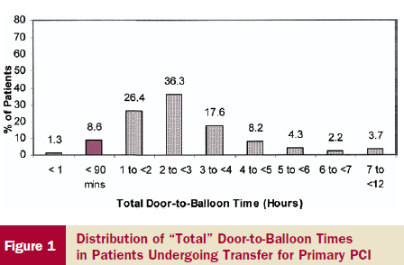

Among transferred primary-PCI patients, only **8.6%** achieved total D2B < 90 min; most fell in the 1–3 hour range. Fig. — total D2B distribution, transfer-in cohort

12

Door-in to Door-out

## The bottleneck is the referring hospital's stay

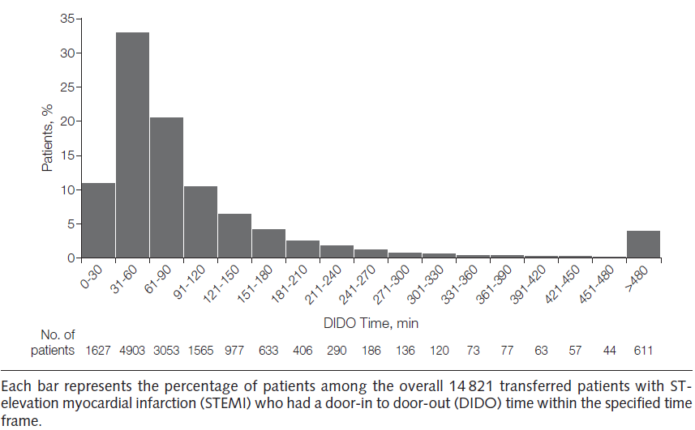

DIDO time in 14,821 transferred STEMI patients — only ~**11% achieved DIDO < 30 min**. Optimal F2D = 30 (DIDO) + 30 (transport) + 60 (in-house) = 120 min; real-world ≈ 150 min. Fig. — DIDO time distribution

13

Solutions · Beyond the Walls

## Re-engineer the process outside the hospital

[figure not shown]

- Shared **inter-hospital duty-staff roster** — always reach the right person
- **LINE instant-messenger groups** — one-to-all, rapid; activation is no longer confined to the ED
- **Uniform activation window**; immediate ECG transfer; Killip class; **activate before arrival**
- ED prepared, **ICU bed reserved**, cardiology & cath team arrive early
- Perform the **ECG in the ambulance** to buy time

14

Prehospital

## Let the ECG happen on the ambulance

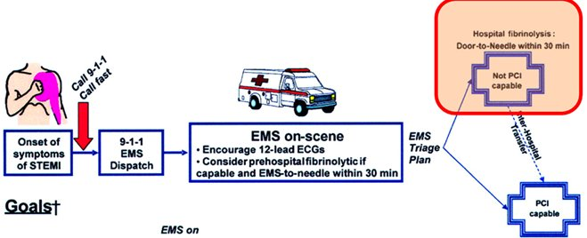

Prehospital 12-lead ECG, transmitted ahead of arrival, lets the team activate before the patient reaches the door. Program photo — prehospital ECG workflow

15

ACS Out-reach Program · 2013

## Open emergent ECG interpretation to partner hospitals

An **emergent ECG-interpretation service**: partner ED physicians join by smartphone and get real-time cardiology reads. **Online since 2013.**

Launched only after resolving the legal / privacy debate — physician-patient relationship, informed consent, data leakage & storage, and physician responsibility were each addressed.

- Partner ED physician evaluates first, then discusses with cardiology
- STEMI: direct line to selected partner hospitals
- Affiliated hospitals: smoother transfer, bed reserved
- Quality improvement is **no longer confined to our own hospital**

16

03

## Re-start · The Last Mile

Beyond 75% — is it worth pushing further? Yes, because diagnosis is still unsolved.

2011–2015 · CONQUER DOOR-TO-ECG

Beyond 75% · Does it worth?

## Faster systems, and the outcome debate

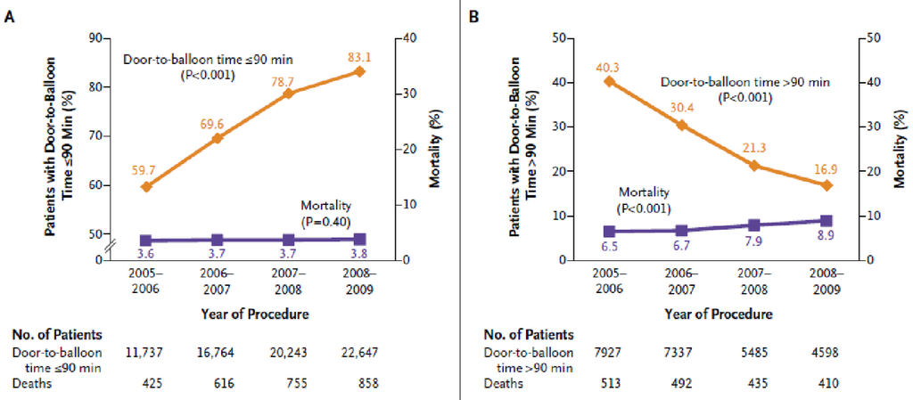

Nationally, D2B ≤ 90 min rose (59.7% → 83.1%) while population mortality changed little — a reminder that **the target rate must be paired with the right patients and real diagnosis**, not chased as a number alone. Fig. — national D2B & mortality trend

18

Why Door-to-ECG?

## Two forces pointed at the same gate

Driver 1

#### Accreditation requirement

Hospital accreditation counts “first ECG < 10 min”. ACS here is defined by **discharge diagnosis** and includes **NSTEMI** — so missed or late ECGs are penalised.

Driver 2

#### Reflection from cases

Reviewing missed cases — including those diagnosed only at discharge, and NSTEMI — all pointed back to one gate: the ECG not done or read early enough.

The remaining obstacle is clear — **diagnosis**. And diagnosis begins with one **electrocardiogram**.

19

Cause-and-Effect · D2E > 10 min

## Why is D2E < 10 min achieved < 75%?

Root-cause (fishbone) analysis — the bottleneck is the time to perform the ECG

#### Process

- No priority rule for ECG
- No rule on when to activate
- No mandate to perform ECG

#### People

- Triage nurses not allowed to do ECG
- ECG technicians busy / unaware of urgency
- Not enough staff for urgent ECG

#### Training

- Insufficient cross-team discussion
- Cases not reviewed one-by-one

#### Environment

- No reserved space for ECG machine
- Machine far from triage; congestion

20

Analysis · D2E > 10 min

## Diagnosis delay, driven by atypical symptoms

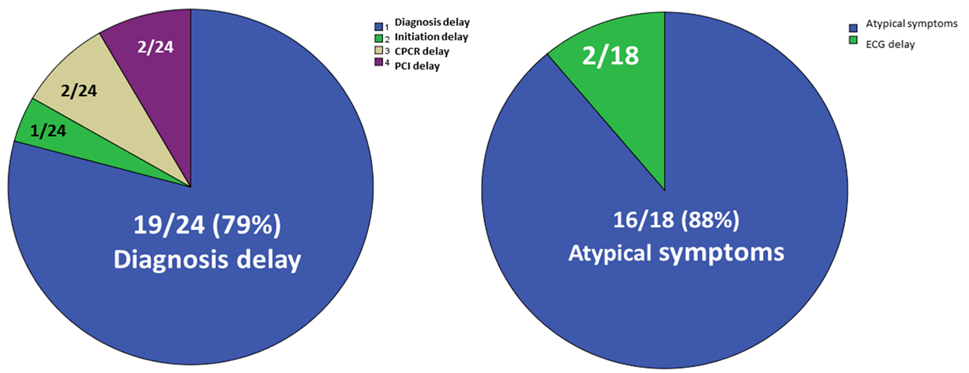

**79%** of D2B delays were diagnosis delays; of those, **88%** were driven by **atypical symptoms** — most commonly epigastralgia, dyspnea and dizziness. Fig. — etiologies of delay

21

Solutions · Fix the ECG Bottleneck

## Space, people, protocol, monitoring

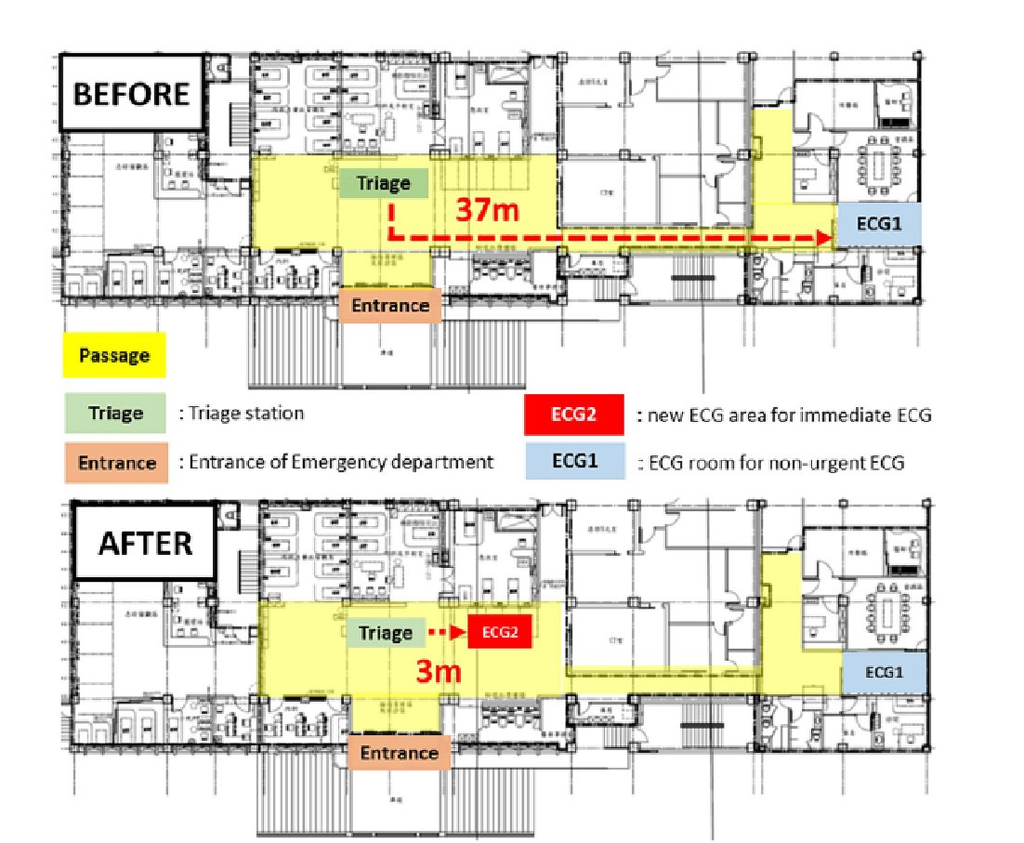

Space

#### ECG at triage

Machine moved to the triage area.

People

#### Nurse-initiated ECG

Triage nurse performs ECG without a physician order.

Protocol

Monitor

#### Audit + reward

Continuous monitoring; reward cases that meet the goal.

22

Protocol · Symptom-triggered ECG

## Five triage red-flags that trigger an immediate ECG

Pre-defined at the triage station; if any one is present, the triage nurse performs a 12-lead ECG at once, without waiting for a physician order

01

#### Chest pain / tightness

Chest pain or chest tightness

02

#### Shortness of breath

Dyspnea

03

#### Upper-abdominal discomfort

If age > 40 years

04

#### Syncope

Transient loss of consciousness

05

#### Hemodynamic instability

SBP < 90 mmHg or HR < 50 / min

Pre-defined criteria — **any one triggers an immediate, nurse-initiated 12-lead ECG**. Atypical presentations are the leading cause of missed STEMI, so the protocol deliberately reaches beyond chest pain. Source: Lee CK et al., PLoS One 2019 (Methods).

23

Do it right, every time

## Standardise, then monitor relentlessly

- A **standardised D2B record sheet** captures each time-stamp and every cause of delay
- Multiple elements monitored regularly — not just the headline number
- Cases that meet the goal are **rewarded**; misses feed the next review

**“Early ≠ more.”** The aim is to move the ECG **earlier** in the pathway — a change of sequence and rules, not of headcount or spending.

24

↺

## Results · The Evidence

A before-and-after quality-improvement study — the data must be honest.

PLOS ONE, 2019 · e0222019

Study Design

## Balanced before / after cohorts

Interventions 2014/6–10 (ECG at triage; nurse-initiated ECG). One year before (N=109) vs one year after (N=105).

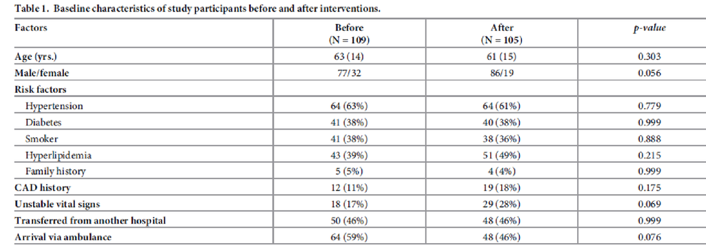

Baseline characteristics were well balanced (age, sex, risk factors; transfer-in 46% both groups). Table 1 — PLOS ONE 2019

26

Primary Result

## The target-achievement rate jumped

Door-to-ECG < 10 min

79.8%→93.3%

p = 0.005

Door-to-Balloon < 90 min

76.2%→91.1%

p = 0.007

Notably, the **median times barely moved** (D2E 4→5 min; D2B 66→65 min). What changed was the **target-achievement rate** — pulling the tail of late patients inside the threshold.

27

Result · Detail

## Median times & target rates, by subgroup

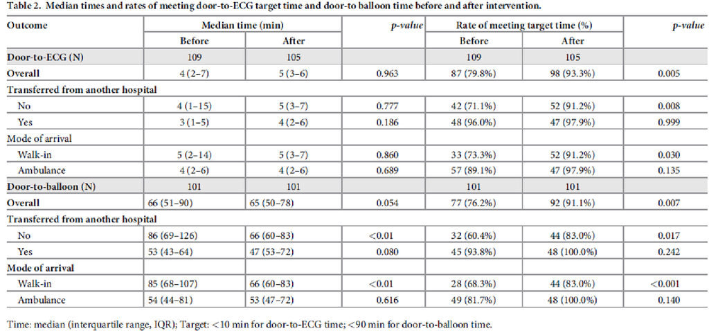

Walk-in D2E < 10 min 73.3% → 91.2% (p=0.030); walk-in D2B < 90 min 68.3% → 83.0% (p<0.001). Transfer-in already near ceiling. Table 2 — PLOS ONE 2019

28

D2E Time Distribution

## The long tail of late ECGs shrank

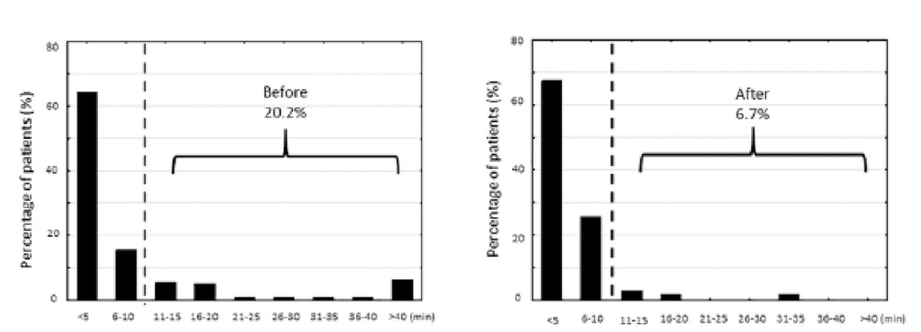

Patients with D2E > 10 min fell from **20.2% → 6.7%**; the distribution compressed toward < 5 min. Fig. — D2E distribution, before vs after

29

Components of Delay

## D2E is the most critical interval

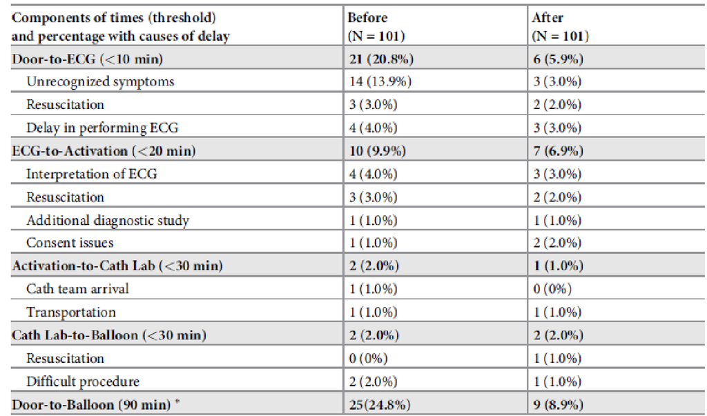

The Door-to-ECG step was the largest delay component (**20.8%**), improving to 5.9%; “unrecognized symptoms” were the leading cause. Table — components of delay, PLOS ONE 2019

30

Multivariable Analysis

## The QI intervention is an independent predictor

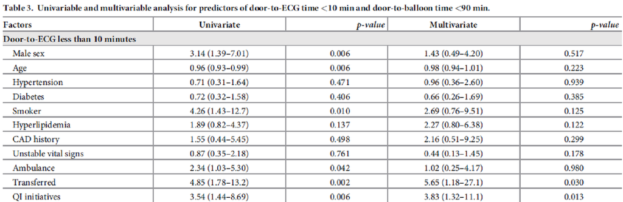

After adjustment, **QI initiatives** independently predicted meeting the D2E target (OR 3.83, 95% CI 1.32–11.1; p=0.013); transferred status OR 5.65. Table 3 — PLOS ONE 2019

31

By Strategy

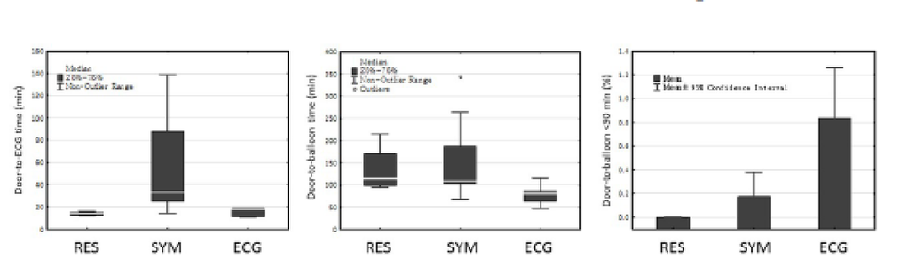

Door-to-ECG time, Door-to-balloon time, and D2B < 90 min rate across successive quality-improvement strategies (RES → SYM → ECG). Fig. — outcomes by strategy stage

32

Fidelity Test

## Did we keep doing it right?

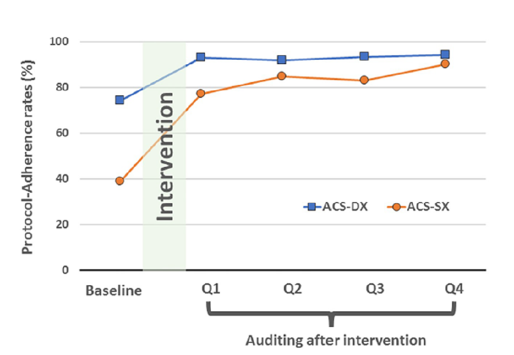

33

Cost Analysis

## Doing it earlier is not doing more

+30%

#### ECG volume

0.259 → 0.338 ECG per patient — earlier, not indiscriminate.

+US$2,425

#### Added cost / month

≈ +485 ECGs × US$5 each.

+14%

#### D2E target gain

Favourable cost-benefit ratio — **no extra staff added**.

Cath-lab and nursing workload were absorbed by re-engineering sequence and rules — not by adding people or money.

34

Recognition

## From best-abstract award to peer-reviewed print

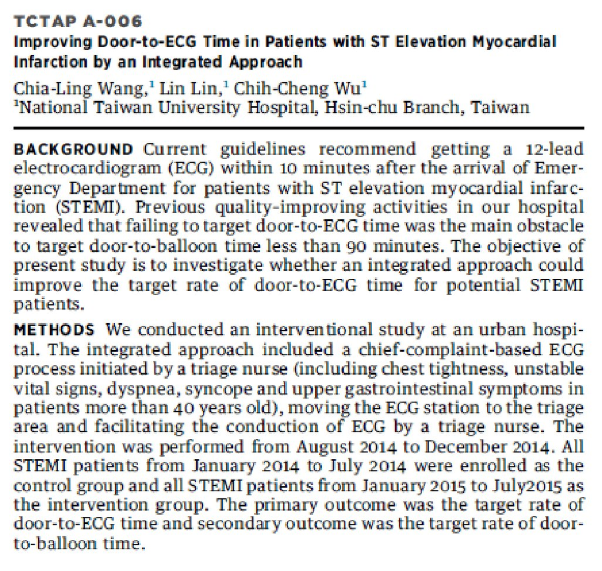

**Best Abstract Award, TCT-AP 2016**, subsequently published in **PLOS ONE, 2019** — a reproducible quality-improvement model. Award — TCT-AP 2016

35

Publication · PLOS ONE 2019

## The paper, at a glance

Lee CK, Meng SW, Lee MH, …, **Hsieh MY**, Huang YC, Huang EP, **Wu CC**. *The impact of door-to-electrocardiogram time on door-to-balloon time after achieving the guideline-recommended target rate.* PLoS One. 2019;14(9):e0222019.

Background

#### The unknown gate

After D2B-Alliance QI strategies, the components of D2B — and the role of D2E — were poorly defined.

Methods

#### Before / after

ED interventions Jun–Oct 2014 (protocol-driven ECG; ECG station + technician moved to triage). 214 STEMI: 109 before / 105 after.

Results

#### D2E is the lever

D2E was the most critical delay (20.8%). D2E<10min 79.8→93.3% (p=.005); D2B<90min 76.2→91.1% (p=.007); benefit only in walk-in patients.

Conclusion

#### Fix triage, fix D2B

Protocol-driven, multidisciplinary ED triage improves D2E and thus D2B<90 — earlier STEMI recognition in ambiguous presentations.

**Adjusted finding:** the QI intervention was an **independent predictor** of meeting the D2E target (OR 3.83, 95% CI 1.32–11.1; p=0.013).

36

Take-home Message

## Five lessons

- **No monitor, no improvement.** What you don't measure, you can't move.
- **Help yourself vs. help everyone.** Quality improvement must reach beyond your own walls.
- **The cause keeps changing.** Re-analyse — today's bottleneck is not yesterday's.
- **Knowing ≠ doing it right.** Implementation fidelity is everything.
- **Communication · Standardization · Monitoring.** The three engines of durable change.

37

References

## References

- ★ This program  
  Lee CK, Meng SW, Lee MH, …, **Hsieh MY**, Huang YC, Huang EP, **Wu CC**. The impact of door-to-electrocardiogram time on door-to-balloon time after achieving the guideline-recommended target rate. **PLoS One.** 2019;14(9):e0222019. [doi:10.1371/journal.pone.0222019](https://doi.org/10.1371/journal.pone.0222019)
- Coyne CJ, Testa N, Desai S, et al. Improving door-to-balloon time by decreasing door-to-ECG time for walk-in STEMI patients. **West J Emerg Med.** 2015;16(1):184–189. [doi:10.5811/westjem.2014.10.23277](https://doi.org/10.5811/westjem.2014.10.23277)
- O'Gara PT, Kushner FG, Ascheim DD, et al. 2013 ACCF/AHA guideline for the management of ST-elevation myocardial infarction. **Circulation.** 2013;127(4):e362–e425. [doi:10.1161/CIR.0b013e3182742cf6](https://doi.org/10.1161/CIR.0b013e3182742cf6)
- Bradley EH, Herrin J, Wang Y, et al. Strategies for reducing the door-to-balloon time in acute myocardial infarction. **N Engl J Med.** 2006;355(22):2308–2320. [doi:10.1056/NEJMsa063117](https://doi.org/10.1056/NEJMsa063117)

38

Thank You

# Time is muscle.

Every minute counts — and it all begins with one ECG done early.

**Mu-Yang Hsieh 謝慕揚**, MD, PhD, FESC · **Chih-Cheng Wu 吳志成**, MD NTUH Hsinchu Branch · Cardiovascular Center

DOOR-TO-BALLOON / DOOR-TO-ECG QUALITY IMPROVEMENT · 2022